```python
%%javascript
IPython.OutputArea.prototype._should_scroll = function(lines) {
    return false;
}
```

```python
# to load images for this tutorial
from IPython.display import Image
import os
path = os.getcwd()

# Math libraries
import numpy as np
import matplotlib.pyplot as plt
import pandas as pd
import seaborn as sns

# Machine Learning Libraries
from sklearn.model_selection import train_test_split
from sklearn.metrics import accuracy_score
```

# Post Goals: Use Binomial Logistic Regression to Classify NFL Wide Receivers by Weight and Height

1. Discuss Assumptions for Binomial Logistic Regression.
2. Demonstrate how to conduct a binomial logistic regression using Sklearn in Python.
3. Demonstrate how to evaluate your model.
4. Demonstrate How to Use Decision Boundaries in Logistic Regressions.

## Load Data

```python
# NFL DATA
fields = ['Team', 'Name', "Status", "Height_in", "Weight_lbs", "Position"]
nfl_file = 'static/data/nfl_df.csv'
nfl_abbr = 'static/data/nfl_position_abbr.csv'
nfl_df = pd.read_csv(nfl_file, usecols=fields)
```

## Confirm Project Meets Binomial Logistic Regression Assumptions

# **Part 1: Provide an Introduction to Logistic Regression and Model Assumptions.**

- Logistic regression is regression algorithm that can be used for classification problems.
- Logistic regression is also known as *Logit Regression*
- There are three major types of logistic regression:
  - *Binomial Logistic Regression*: there are only two possible outcomes (yes/no, cat 1 or cat 2).
  - *Multinomial Logistic Regression*: there are three or more possible outcomes without order. Example: planet, start, comet
  - *Ordinal Logistic Regression*: there are three or more possible outcomes with ordering. Example: movie ratings from boring, okay, good, great.
- The focus of this post is the binomial logistic regression
- Binomial Logistic regression is used to explain the relationship between a dependent binary variable and one or more continuous or categorical data (nominal, ordinal, interval, or ratio-level) independent variables.
- **In other words:** Binomial Logistic regression is used to estimate the probability that an instance belongs to a specific class. Does the observation fall into one of two categories?
- A decision boundary is used to set a threshold for prediction making. For binary classification, if an instance is less than 50%, it is classified in one category, and if is greater or equal to 50%, it is classified in the 2nd cagetory.
- Decision boundaries can be linear or non-linear. Polynomial order can be increased to get a more complex decision boundary
- Example of logistic regression problems:
  - What is the probability that email is spam? (spam/ not spam)
  - What is the probability that transaction is fraud? (yes/no)
  - What is the probability that this tissue sample is cancerous? (yes/no)
- Instances greater than 50% are labeled positive class, "1" .
- Instances less than 50% are labeled negative class, "0".
- **Major Assumptions**
1. Dependent variable should be dichotomous in nature (yes/no, present/absent, male/female etc). If your dependent variable is continuous, you need to carry out a multiple regression analysis instead.  
   The dependent variable in this study is dichotomous (wide receiver or not wide receiver).
2. You have one or more independent variables, which can be either continuous variables (i.e., an interval or ratio variable) or nominal variables.  
   The independent variables for this study are both continuous variables (player weight in lbs and player height in inches).
3. There should be independence of observations.  
   Each instance in this dataset are individual players. Each instance is independent.
4. The categories of the dichotomous dependent variable and all your nominal independent variables should be mutually exclusive and exhaustive.  
   There are no nominal independent variables in this study.
5. There should be a bare minimum of 15 cases per independent variable (although some recommend as high as 50 cases per independent variable).  
   There are over 2652 observations, well over the minimum for this method.
6. There needs to be a linear relationship between any of the continous independent variables and the logit transformation of the dependent variable. The Box-Tidwell (1967) procedure can be used to test for linearity.  
   Box-Tindell test was conducted using SPSS as described by [Laerd Statistics](https://statistics.laerd.com/premium/spss/blr/binomial-logistic-regression-in-spss-6.php#dealing-with-nonlinearity)
7. Your data must not show multicollinearity.  
   A Variable Inflation Factor test was conducted on the weight and height features and the result suggest high multicollinearity. To resolve this issue, this binary logistic regression will only use 1 of these two features, the weight of players.
8. There should be no significant outliers, high leverage points or highly influential points.  
   Boxplot and z-score analysis were conducted on the key independent variables and no evidence to suggest outliers exist in either of these features.

## Test for Multicollinearity Using Variable Inflation Factors (VIF)

```python
import statsmodels.api as sm
from statsmodels.stats.outliers_influence import variance_inflation_factor

def calc_vif(X):

    # Calculating VIF
    vif = pd.DataFrame()
    vif["variables"] = X.columns
    vif["VIF"] = [variance_inflation_factor(X.values, i) for i in range(X.shape[1])]

    return(vif)
```

```python
X = nfl_df.iloc[:,3:5]
calc_vif(X)
```

|  | variables | VIF |
| --- | --- | --- |
| 0 | Height_in | 40.901476 |
| 1 | Weight_lbs | 40.901476 |

# **Comments on VIF:**

- The VIF is 1 divided by (1 - R^2).
- The VIF starts at 1 and there is no upper limit.
- If VIF is 1, then no correlations between independent variables.
- If VIF exceeds 5, it indicates multicollinearity between the independent variables.
- In this case, the VIF for both variables are higher than 5 and suggest multicollinearity, as a result, only one variable will serve as the independent feature. **weight**

## Test for Outliers via BoxPlot

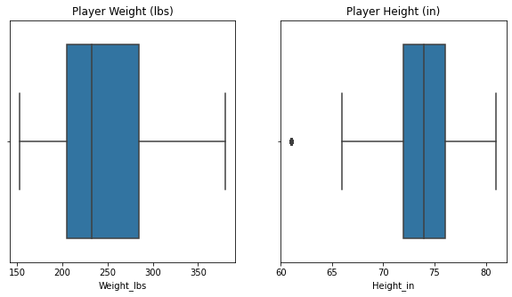

```python
fig, axes = plt.subplots(1, 2, figsize=(10,5))
sns.boxplot(x=nfl_df["Weight_lbs"], ax=axes[0])
axes[0].set_title('Player Weight (lbs)')
sns.boxplot(x=nfl_df["Height_in"], ax=axes[1])
axes[1].set_title('Player Height (in)')
plt.savefig("static/images/Outlierboxplots.png", bbox_inches='tight', dpi=300)
plt.show()
```

## Test for Outliers via Z-score

```python
from scipy import stats
import numpy as np
z_height = np.abs(stats.zscore(nfl_df['Height_in']))
threshold = 3
print(np.where(z_height > threshold))
```

```
(array([], dtype=int64),)
```

# **Comments:**

## Demonstrate how to conduct a binomial logistic regression using Sklearn in Python.

## Encoding Target Variable

```python
# Create target (Y) for players that are wide receivers
nfl_df["target"] = np.where(nfl_df['Position'] == 'WR', 1, 0)
```

### Prepare Data for plotting and linear regression

- np.c_ method translates slice objects to concatenation along the second axis.
- Stack 1-D arrays as columns into a 2-D array.
- Documentation as of 5/16/20: https://numpy.org/devdocs/reference/generated/numpy.c_.html
- This is important for matrix calculations

```python
# Assign data to dependent and independent variables
X = np.c_[nfl_df["Weight_lbs"]]
y = np.c_[nfl_df["target"]]
```

## Train Logistic Regression Model

```python
from sklearn.linear_model import LogisticRegression
# Split and Train Data
X_train, X_test, y_train, y_test=train_test_split(X,y,test_size=0.25,random_state=0)

logreg = LogisticRegression(solver="lbfgs", random_state=42)
#log_reg.fit(X, np.ravel(y))
logreg.fit(X_train, np.ravel(y_train))
```

```
LogisticRegression(random_state=42)
```

## Visualize the Model's Estimated Probabilities

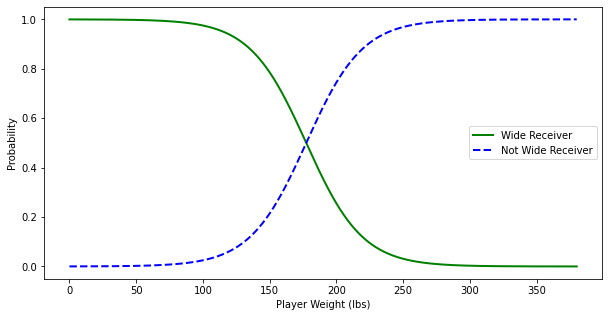

```python
plt.figure(figsize=(10, 5))
X_new = np.linspace(0, X.max(), 1000).reshape(-1, 1)
y_proba = logreg.predict_proba(X_new)

plt.plot(X_new, y_proba[:, 1], "g-", linewidth=2, label="Wide Receiver")
plt.plot(X_new, y_proba[:, 0], "b--", linewidth=2, label="Not Wide Receiver")
plt.legend()
plt.xlabel("Player Weight (lbs)")
plt.ylabel("Probability")
plt.savefig("static/images/model_estimated_prob.png", bbox_inches='tight', dpi=300)
plt.show()
```

```python
# make predictions based on weight and height
DeSean_Jackson = [177]
Marshal_Yanda = [305]
two_tests = logreg.predict([DeSean_Jackson, Marshal_Yanda])
print(f'The examples tests the weight of NFL players\nMarris Harrison is predicted: {two_tests[0]}\nMarshal Yanda is predicted {two_tests[1]}')
```

```
The examples tests the weight of NFL players
Marris Harrison is predicted: 1
Marshal Yanda is predicted 0
```

# **Comments:**

- The model was able to correctly predict the class for Marris Harrison, while classifying Marshal Yanda as a non wide receiver.
- Now we need to evaluate the model on the test data.

## Demonstrate how to evaluate your model.

## Evaluate Model Using Confusion Matrix

```python
# create an array that contains the predictions for the test set
y_pred = logreg.predict(X_test)
```

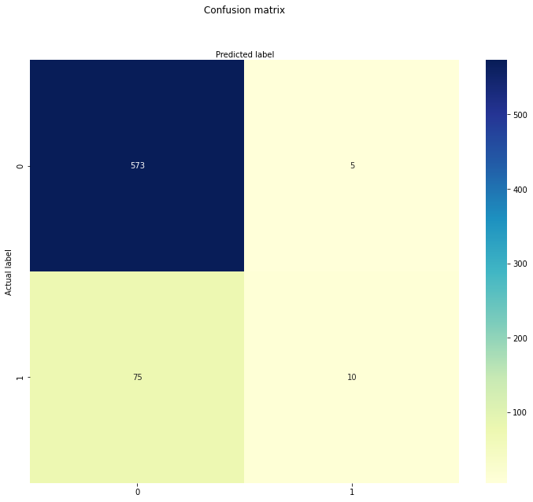

```python
# import the metrics class
from sklearn import metrics
cnf_matrix = metrics.confusion_matrix(y_test, y_pred)

class_names=[0,1] # name  of classes
fig, ax = plt.subplots(figsize=(10,8))
tick_marks = np.arange(len(class_names))
plt.xticks(tick_marks, class_names)
plt.yticks(tick_marks, class_names)
# create heatmap
sns.heatmap(pd.DataFrame(cnf_matrix), annot=True, cmap="YlGnBu" ,fmt='g')
ax.xaxis.set_label_position("top")
plt.tight_layout()
plt.title('Confusion matrix', y=1.1)
plt.ylabel('Actual label')
plt.xlabel('Predicted label')
plt.savefig("static/images/confusion_matrix.png", bbox_inches='tight', dpi=300)
plt.show()
```

```python
print("Accuracy:",metrics.accuracy_score(y_test, y_pred))
print("Precision:",metrics.precision_score(y_test, y_pred))
print("Recall:",metrics.recall_score(y_test, y_pred))
```

```
Accuracy: 0.8793363499245852
Precision: 0.6666666666666666
Recall: 0.11764705882352941
```